# Campaign Contributions and Bureaucratic Oversight

Looking at letters that are explicitly pro- or anti-business, Democrats write more anti-business letters, whereas, for Republicans, it depends on chamber control. When in the majority, Republicans write more pro-business letters.

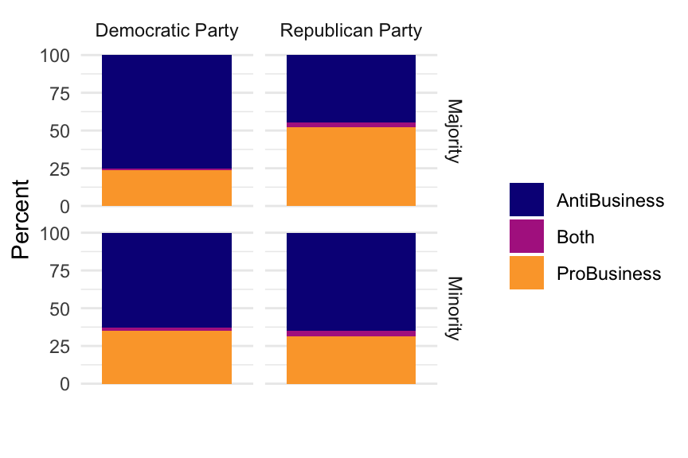

```r
d %>%
  count(party_name, letter_position, majority) %>%
    filter(party_name != "Independent",
           letter_position != "Other",
         !is.na(letter_position),
         !is.na(majority)) %>%
  group_by(party_name, majority) %>%
  mutate(percent = n / sum(n) * 100 ) %>%
  ggplot() +
  aes(y = percent, x = "", fill = letter_position) +
  geom_col(position = "stack") +
  facet_grid(majority ~ party_name)+
  scale_fill_viridis_d(option = "C", end = .8) +
  labs(x = "",
       fill = "",
       y = "Percent") +
  theme_minimal() +
  theme(panel.grid.major.x  = element_blank())
```

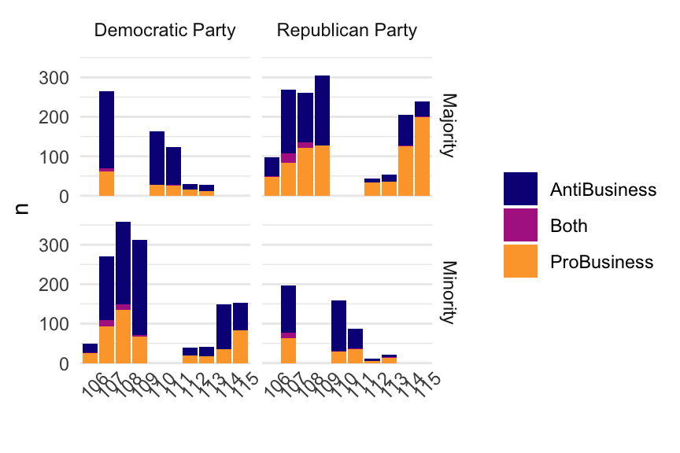

```r
d %>% filter(party_name != "Independent",
             letter_position != "Other",
             !is.na(letter_position),
             !is.na(majority)) %>%
  count(party_name, letter_position, majority, congress) %>%
  ggplot() +
  aes(y = n, x = factor(congress), fill = letter_position) +
  geom_col(position = "stack") +
  facet_grid(majority ~ party_name)+
  scale_fill_viridis_d(option = "C", end = .8) +
  labs(x = "",
       fill = "",
       y = "n") +
  theme_minimal() +
  theme(panel.grid.major.x  = element_blank(),
        axis.text.x = element_text(angle = 45))
```

## Coding of constituent type

Our coding of letter type is a mix of hand-coding “Pro-business” and “Constituent” letters, as well as some coding rules applied to letters that were not put in either group by human coders using [inductively-developed coding rules](https://github.com/judgelord/correspondence/blob/master/agencies/DOE_FERC.R).

FERC has an especially high ratio of letters written on behalf of businesses compared to other agencies that mostly receive letters from legislators on behalf of their constituents.

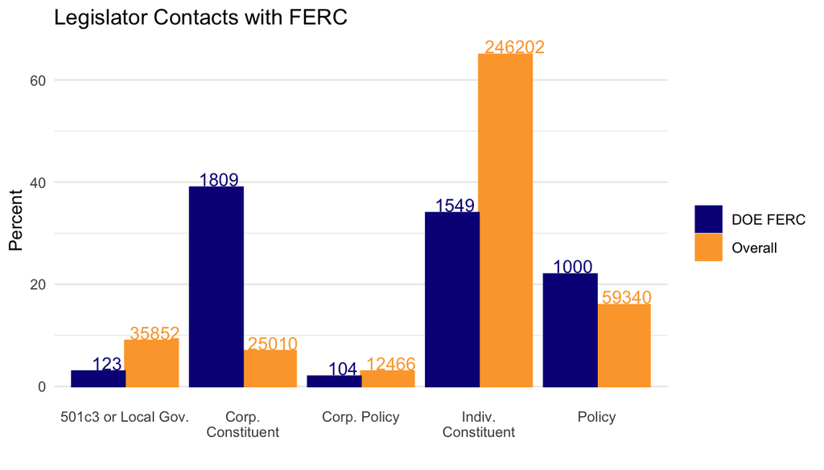

```r
all_percent <- all_contacts %>%
  filter(Type != "To be coded") %>%
  mutate(total = n()) %>%
  group_by(Type, total) %>% summarise(nT = n()) %>%
  mutate(percent = 100*round(nT/total, 2) ) %>%
  mutate(agency = "Overall") %>%
  ungroup()


d_percent <- d %>%
  filter(Type != "To be coded") %>%
  mutate(total = n()) %>%
  group_by(Type, total) %>% summarise(nT = n()) %>%
  mutate(percent = 100*round(nT/total, 2) ) %>%
  mutate(agency = "DOE FERC") %>%
  ungroup()

full_join( all_percent, d_percent)%>%
  mutate(Type = ifelse(str_detect(Type, "Const"), Type %>% str_replace(" Const", "\nConst"), Type)) %>%
  ggplot() +
  aes(x = Type, y = percent, fill = agency, color = agency, label = nT) +
  geom_col(position = "dodge") +
  geom_text(vjust = -.1,
            aes(hjust = ifelse(agency == "Overall", -.1,1.1))) +
  labs(x = "",
       fill = "",
       color = "",
       y = "Percent", #paste("Number of Contacts, N =", sum(nrow(all_contacts))),
       title = "Legislator Contacts with FERC") +
  theme(panel.background = element_blank(),
        axis.ticks = element_blank(),
        axis.text.x.top = element_text()) +
  scale_color_viridis_d(option = "C", end = .8) +
  scale_fill_viridis_d(option = "C", end = .8) +
    theme_minimal() +
  theme(panel.grid.major.x  = element_blank())
```

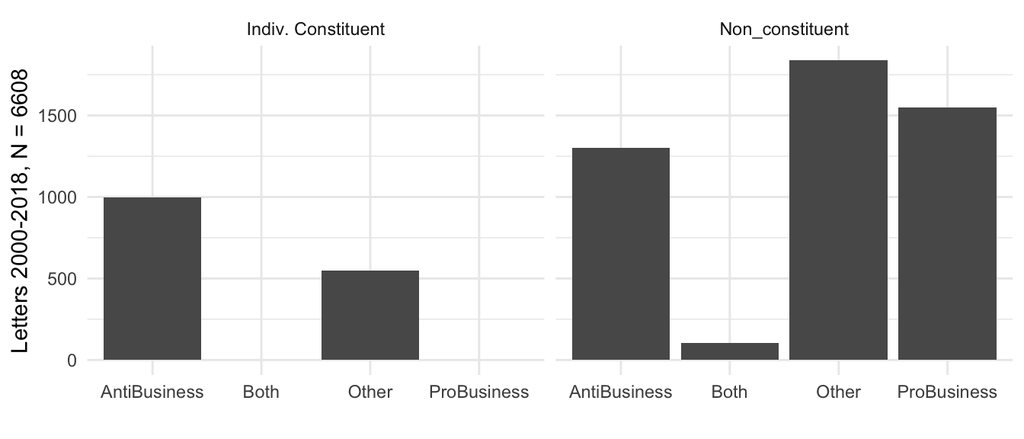

```r
d  %>%
  filter(Constituent != "Not coded") %>%
  ggplot() +
      theme_minimal() +
  aes(x = letter_position) +
  geom_bar() +
  facet_wrap("Constituent") +

  labs(x = "",
       y = paste("Letters 2000-2018, N =", as.character(d%>%drop_na(letter_position, Constituent) %>% nrow() %>% as.character() )))
```

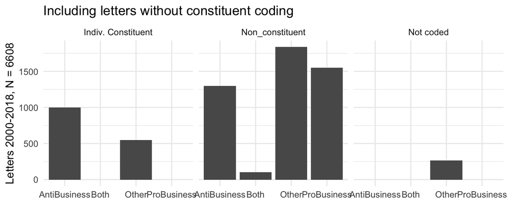

```r
d  %>%
  ggplot() +
      theme_minimal() +
  aes(x = letter_position) +
  geom_bar() +
  facet_wrap("Constituent") +
  labs(title = "Including letters without constituent coding",
       x = "",
       y = paste("Letters 2000-2018, N =", as.character(d %>% nrow() %>% as.character() )))
```

# Members

### Senators vs. state population

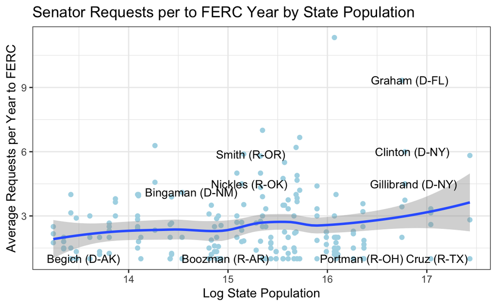

```r
d %>%
  filter(chamber == "Senate") %>%
    group_by(name_state, year, pop2010) %>% summarise(n = n()) %>%
    group_by(name_state, pop2010) %>% summarise(mean = mean(n)) %>% ungroup() %>%
    ggplot() +
    geom_point(aes(x = log(pop2010), y = mean), color = "light blue") +
  geom_smooth(aes(x = log(pop2010), y = mean)) +
  geom_text(aes(x = log(pop2010),
                y = mean,
                label = ifelse(mean > mean(mean)*1.5 | mean < mean(mean)*0.5,
                               name_state, "")),
            check_overlap = TRUE,
            size = 3.5,
            hjust = .4) +
  theme_bw() +
  labs(title = "Senator Requests per to FERC Year by State Population",
       x = "Log State Population",
       y = "Average Requests per Year to FERC")
```

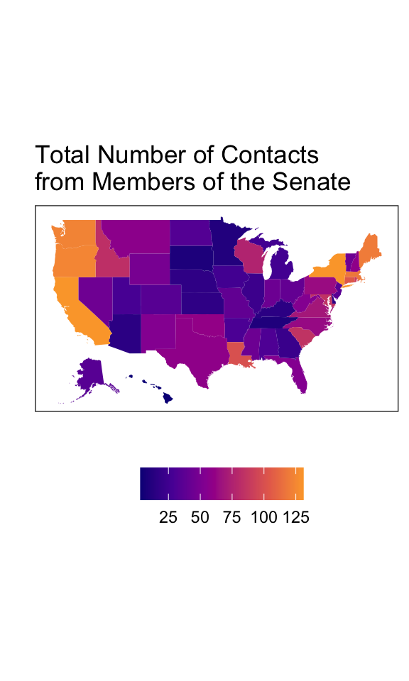

```r
Chamber = "Senate"

d %>%
  ungroup() %>%
  filter(chamber == Chamber) %>%
  group_by(state) %>% summarise(n = n()) %>%
# map_id creates the aesthetic mapping to the state name column
ggplot() +
  # map points to the fifty_states shape data
  geom_map(aes(map_id = state, fill = n), map = fifty_states) +
  expand_limits(x = fifty_states$long, y = fifty_states$lat) +
  coord_map() +
  scale_x_continuous(breaks = NULL) +
  scale_y_continuous(breaks = NULL) +
  labs(x = "", y = "", title = paste("Total Number of Contacts\nfrom Members of the", Chamber)) +
  scale_fill_viridis_c(option = "C", end = .8) +
  theme(legend.position = "bottom", legend.title = element_blank(),
        panel.background = element_blank()) # + facet_grid(. ~ Constituent)
```

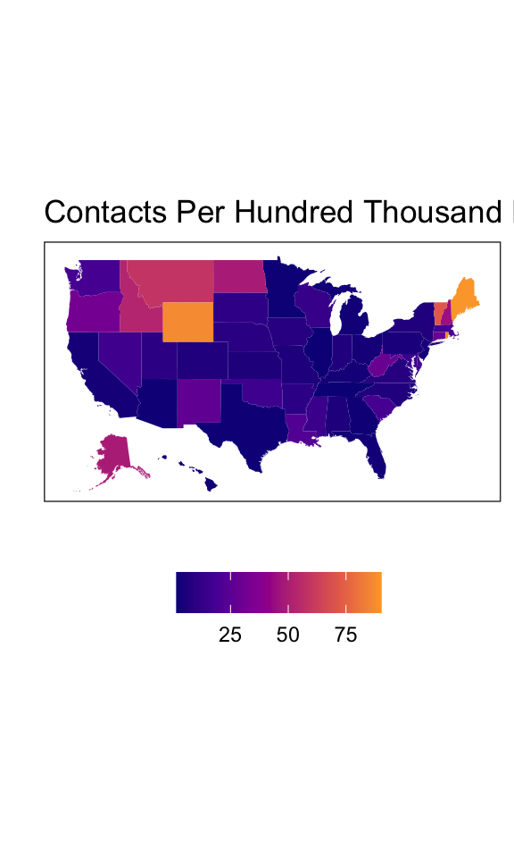

```r
d %>%
  ungroup() %>%
  filter(chamber == Chamber) %>%
  group_by(state, pop2010) %>% summarise(n = n()) %>% ungroup() %>%
  mutate(Per_Capita = n/pop2010*1000000) %>%
  # map_id creates the aesthetic mapping to the state name column in your data
  ggplot() +
  # map points to the fifty_states shape data
  geom_map(aes(map_id = state, fill = Per_Capita), map = fifty_states) +
  expand_limits(x = fifty_states$long, y = fifty_states$lat) +
  coord_map() +
  scale_x_continuous(breaks = NULL) +
  scale_y_continuous(breaks = NULL) +
  labs(x = "", y = "", title = paste("Contacts Per Hundred Thousand Residents from Members of the", Chamber)) +
  scale_fill_viridis_c(option = "C", end = .8) +
  theme(legend.position = "bottom",
        legend.title = element_blank() )#+facet_grid(. ~ Constituent)
```

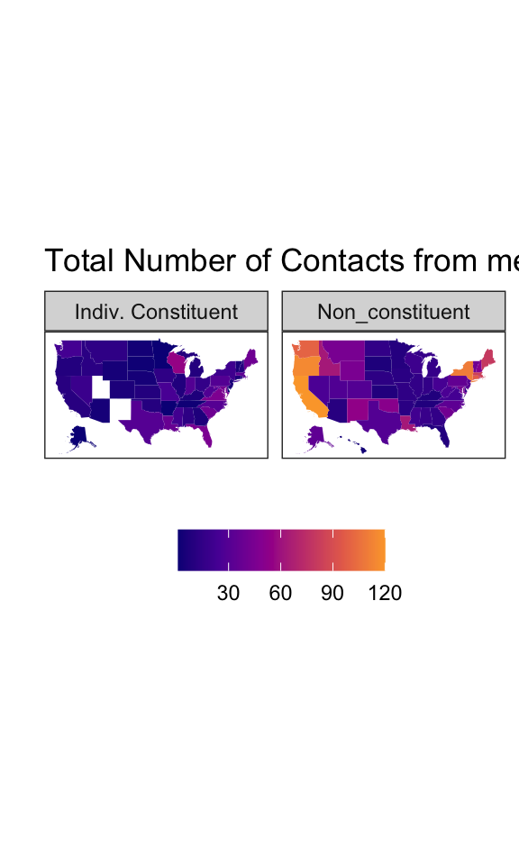

```r
# By type2
d %>%
  filter(chamber == Chamber) %>%
  filter(Constituent != "Not coded") %>%
  group_by(state, Constituent) %>% summarise(n = n()) %>%
# map_id creates the aesthetic mapping to the state name column
ggplot() +
  # map points to the fifty_states shape data
  geom_map(aes(map_id = state, fill = n), map = fifty_states) +
  expand_limits(x = fifty_states$long, y = fifty_states$lat) +
  coord_map() +
  scale_x_continuous(breaks = NULL) +
  scale_y_continuous(breaks = NULL) +
  labs(x = "", y = "", title = paste("Total Number of Contacts from members of the", Chamber)) +
  scale_fill_viridis_c(option = "C", end = .8) +
  theme(legend.position = "bottom", legend.title = element_blank(),
        panel.background = element_blank()) + facet_grid(. ~ Constituent)
```

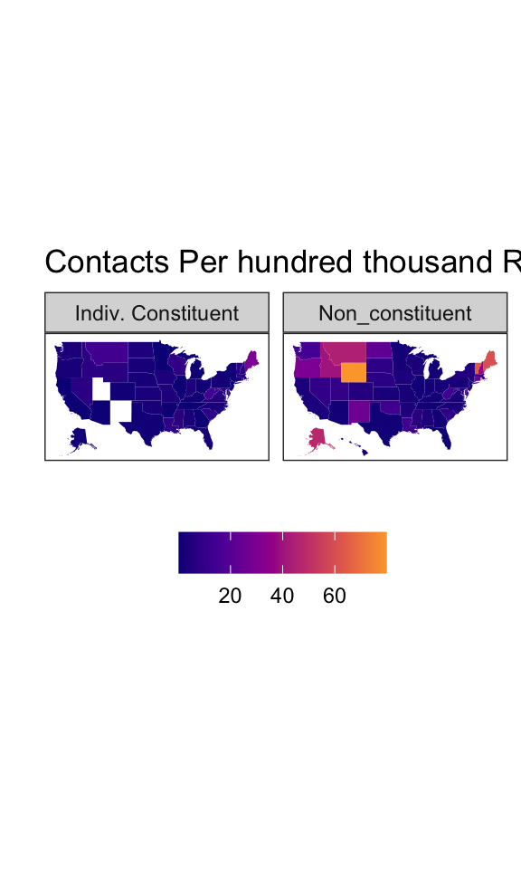

```r
d %>%
  filter(chamber == Chamber) %>%
  filter(Constituent != "Not coded") %>%
  group_by(state, pop2010, Constituent) %>% summarise(n = n()) %>% ungroup() %>%
  mutate(Per_Capita = n/pop2010*1000000) %>%
  # map_id creates the aesthetic mapping to the state name column in your data
  ggplot() +
  # map points to the fifty_states shape data
  geom_map(aes(map_id = state, fill = Per_Capita), map = fifty_states) +
  expand_limits(x = fifty_states$long, y = fifty_states$lat) +
  coord_map() +
  scale_x_continuous(breaks = NULL) +
  scale_y_continuous(breaks = NULL) +
  labs(x = "", y = "", title = paste("Contacts Per hundred thousand Residents from Members of the", Chamber)) +
  scale_fill_viridis_c(option = "C", end = .8) +
  theme(legend.position = "bottom",
        legend.title = element_blank() )+
  facet_grid(. ~ Constituent)
```

### Members who contact FERC more than average:

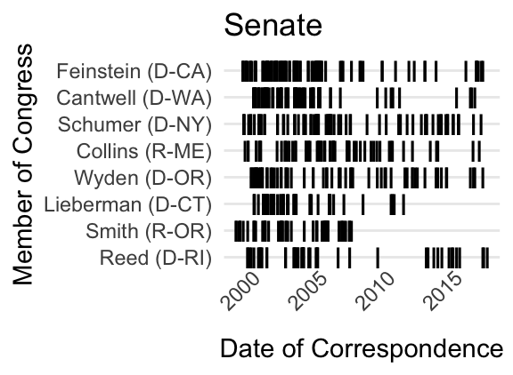

```r
# barcode plot of committee members


Chamber <- "Senate"

# member by year by agency
d %>%
  filter(chamber == Chamber) %>%
  group_by(name_state) %>% mutate(n = n()) %>% ungroup() %>%
  mutate(percent = percent_rank(n)) %>%
  filter(percent > .80) %>%
  ggplot() +
  geom_point(
    aes(x = DATE,
        y = reorder(name_state, n) ),
    # alpha = .6,
    shape = 73,
    size = 4
  ) +
  labs(title = paste(Chamber),
       y = paste("Member of Congress"),
       x = "Date of Correspondence" ) +
  theme_minimal()+
  theme(panel.grid.major.x = element_blank(),
        panel.grid.minor.x = element_blank(),
        axis.text.x = element_text(angle = 45))
```

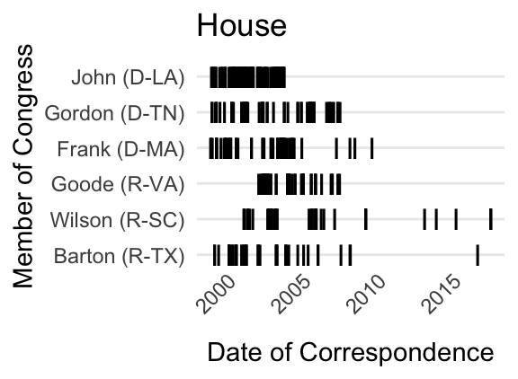

```r
Chamber <- "House" # "House" #

# member by year by agency
d %>%
  filter(chamber == Chamber) %>%
  group_by(name_state) %>% mutate(n = n()) %>% ungroup() %>%
    mutate(percent = percent_rank(n)) %>%
  filter(percent > .90) %>%
  #filter(n > mean(n)) %>%
  ggplot() +
  geom_point(
    aes(x = DATE,
        y = reorder(name_state, n) ),
    # alpha = .6,
    shape = 73,
    size = 4
  ) +
  labs(title = paste(Chamber),
       y = paste("Member of Congress"),
       x = "Date of Correspondence" ) +
  theme_minimal() +
  theme(panel.grid.major.x = element_blank(),
        panel.grid.minor.x = element_blank(),
        axis.text.x = element_text(angle = 45))
```

```r
all_contacts %>%
  filter(congress >109) %>%
  mutate(FERC = agency == "DOE_FERC") %>%
  count(chamber, FERC, name_state, state) %>%
  spread(key = "FERC", value = "n", 0) %>%
  mutate(ShareToFERC = round(`TRUE`/(`TRUE`+`FALSE`),2) ) %>%
  arrange(-ShareToFERC) %>%
  mutate(total = `TRUE` + `FALSE`) %>%
  select(name_state, chamber, total, ShareToFERC) %>%
  filter(ShareToFERC>.3) %>%
  knitr::kable(caption = "Members who contact FERC more, relative to other agencies" )
```

Members who contact FERC more, relative to other agencies

| name_state | chamber | total | ShareToFERC |
| --- | --- | --- | --- |
| Lesko (AZ) | House | 3 | 0.67 |
| Mooney (WV) | House | 53 | 0.34 |

```r
all_contacts %>%
  filter(congress >109) %>%
  mutate(FERC = agency == "DOE_FERC") %>%
  count(chamber, congress, FERC, name_state, state) %>%
  spread(key = "FERC", value = "n", 0) %>%
  mutate(ShareToFERC = round(`TRUE`/(`TRUE`+`FALSE`),2) ) %>%
  arrange(-ShareToFERC) %>%
  mutate(total = `TRUE` + `FALSE`) %>%
  select(name_state, chamber, congress, total, ShareToFERC) %>%
    filter(total >10) %>%
  top_n(10) %>%
  knitr::kable(caption = "Members who contact FERC more in a Congress, relative to other agencies")
```

Members who contact FERC more in a Congress, relative to other agencies

| name_state | chamber | congress | total | ShareToFERC |
| --- | --- | --- | --- | --- |
| Mooney (WV) | House | 115 | 28 | 0.54 |
| Wu (OR) | House | 110 | 47 | 0.32 |
| Olson (TX) | House | 115 | 35 | 0.26 |
| Murphy (CT) | House | 110 | 35 | 0.23 |
| Lynch (MA) | House | 114 | 56 | 0.23 |
| Rush (IL) | House | 115 | 24 | 0.21 |
| Mckinley (WV) | House | 115 | 41 | 0.20 |
| Wilson (OH) | House | 110 | 16 | 0.19 |
| Bridenstine (OK) | House | 115 | 21 | 0.19 |
| Porter (NV) | House | 110 | 17 | 0.18 |

## Interesting cases

From [Sen. Dianne Feinstein’s website section on accomplishments in the 107th Congress](https://www.feinstein.senate.gov/public/index.cfm?p=107th-congress):

"**Significant Negotiations:**

Just and Reasonable Electricity Rates – With the electricity rates skyrocketing because of market manipulation during the California energy crisis, Senator Feinstein lobbied the President, other members of Congress, and the Federal Energy Regulatory Commission to cap electricity and natural gas rates. She also introduced S.26, which would have authorized the Department of Energy to impose price caps, S.287, to direct FERC to impose the cost of service-based rates on electricity and S.764 to give FERC the choice of either price caps based on demand or cost of service rates. While the bills did not come up for a vote, Senator Feinstein was finally successful in convincing FERC, after new commissioners were sworn in, to impose price caps on their own."

From the [West Virginia Gazette](https://www.wvgazettemail.com/news/politics/wv-republican-congressmen-s-funding-dwarfs-challengers/article_2e9bcb96-9021-56a6-ac0f-57f2917a6bef.html):

In an article titled “Republican congressmen’s funding dwarfs challengers’,” the Charleston Gazee-Mail noted how energy companies backed Representative Alex Mooney (R-WV). Indeed, Mooney wrote to FERC more than any other agency, always on behalf of energy projects, mostly pipelines. In 2017, he wrote on behalf of the Dominion Energy Supply Header Project, National Fuel Gas Distribution Corporation’s [Northern Access Project](https://www.natfuel.com/supply/NorthernAccess2016/default.aspx), Transcontinental Gas Pipe Line Company’s [Atlantic Sunrise Project](https://blog.williams.com/projects-and-operations/atlantic-sunrise/atlantic-sunrise-project-placed-into-full-service/), Columbia Gas Transmission’s proposed Eastern Panhandle Expansion project, Columbia’s WB Xpress Project to build new compressor stations, In 2015 he wrote on behalf of the Columbia s Mountaineer XPress Project, Atlantic Coast Pipeline ACP project. The parent companies of these projects spend millions of dollars on lobbying (Lobbyview). The WV Gazette reports funding from Dominion that is not included in Lobbyview totals.

## Committee Leadership

```r
dcommittees %>%
  mutate(chair = str_remove(chair,"[0-9]* |^NA "),
         committee = paste(chamber, committee))%>%
  dplyr::select(committee, position, chair, DATE, assigneddate, terminationdate) %>%
  distinct() %>%
  filter(str_detect(committee, "ENERGY$|ENVIRONMENT|NATURAL")) %>%
  mutate(position = ifelse(position == "Other", NA, position)) %>%
  #filter(# !is.na(position),chair_since_2007 == T) %>%
  drop_na(chair) %>%
  dplyr::select(DATE, chair, position, assigneddate, terminationdate, committee) %>%
  distinct() %>%
  ggplot() +
  geom_point(
    aes(x = DATE,
        y = chair),
    shape = 73,
    size=2
  ) +
  geom_segment(aes(y = chair, yend = chair,
                   x = assigneddate, xend = terminationdate,
                   linetype = factor(position)),
               position = position_nudge(y = -0.3)) +
  labs(title = paste("Letters to FERC from Committee Leadership"),
       y = "",
       x = "",
       linetype = "Leadership position") +
  scale_y_discrete(position = "right") +
  theme(
    strip.text.y = element_text(angle = 180, size = 5),
    # legend.title = element_blank(),
    axis.text.y = element_text(size=5),
    axis.text.x = element_text(angle = 0)
  ) +
  facet_grid(committee ~ ., scales = "free_y", space = "free_y", switch = "both")
```

[output not shown]

## Many letters to FERC are cosigned

For each member, we have letter counts by Congress and letter position, as well as contributions by energy and non-energy sector PACs:

```r
#A rough under-estimate based on whether "et al" or "&" appears in the summary:

FERC_letters %>%
  filter(year>1999,
         year<2019) %>%
  group_by(ID) %>%
  top_n(1) %>%
  mutate(probably_cosigned = ifelse(str_detect(SUBJECT, "et al"), "et al",
                                 ifelse(str_detect(SUBJECT, "&"), "&", " neither"))) %>%
  group_by(year, probably_cosigned) %>%
  tally %>%
  ggplot() +
  aes(x = year, y = n, fill = probably_cosigned) +
  geom_col() +
  scale_fill_viridis_d(option = "C", end = .8)
```

[output not shown]

Cosigned letters identified by coders

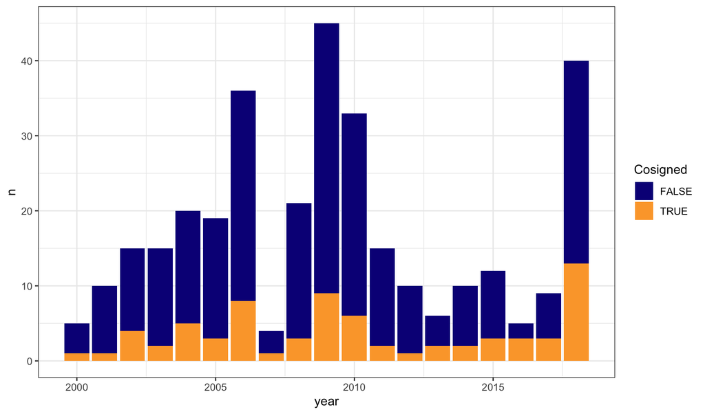

```r
FERC_letters %>%
  filter(!is.na(Freelancer),
         year>1999,
         year<2019) %>%
    mutate(Cosigned = ifelse(!is.na(Cosigned_House)|!is.na(Cosigned_Senate),
                                 T, F)) %>%
  select(Cosigned, year, Notes) %>% distinct() %>%
  count(year, Cosigned) %>%
  ggplot() +
  aes(x = year, y = n, fill = Cosigned) +
  geom_col() +
  scale_fill_viridis_d(option = "C", end = .8)
```

# PAC Contributions from the Energy Sector

Using CRP industry codes and contribution data, sum up sector-level contributions by a member per cycle, matching a congress with the cycle when it was elected (e.g., 116th Congress = 2018 cycle). Code to get PAC contributions from CRP data [here](https://judgelord.github.io/correspondence/functions/pacs-from-crp.html). PAC contributions per cycle are saved as data/pac_amounts.Rdata.

(For the next paper, we will look at specific company-legislator diads, see company-crosswalk.Rmd)

```r
library(tidyverse)

load(here::here("data/pac_amounts.Rdata"))

pac_amounts %<>%
  # select useful vars
  select(icpsr, party_name, congress, cycle, industry, amounts) %>% distinct() %>%
  # fix cycle
  mutate(cycle = (congress - 107)*2 + 2000)

pac_amounts %<>% filter(cycle>1997)

# drop NA industry
pac_amounts %<>% filter(!is.na(industry))

pac_amounts %<>%
  mutate(PAC_contributions = amounts)

pac_amounts %>% top_n(10) %>% kable()
```

| icpsr | party_name | congress | cycle | industry | amounts | PAC_contributions |
| --- | --- | --- | --- | --- | --- | --- |
| 21300 | Democratic Party | 116 | 2018 | other | 5213194 | 5213194 |
| 29735 | Republican Party | 115 | 2016 | other | 7818774 | 7818774 |
| 14503 | Republican Party | 113 | 2012 | other | 7101172 | 7101172 |
| 29735 | Republican Party | 112 | 2010 | other | 6410524 | 6410524 |
| 29386 | Republican Party | 112 | 2010 | other | 5321460 | 5321460 |
| 29512 | Republican Party | 111 | 2008 | other | 8073652 | 8073652 |
| 29936 | Republican Party | 109 | 2004 | other | 4883650 | 4883650 |
| 29548 | Republican Party | 109 | 2004 | other | 5356792 | 5356792 |
| 29305 | Democratic Party | 109 | 2004 | other | 6988191 | 6988191 |
| 14910 | Republican Party | 109 | 2004 | other | 5171008 | 5171008 |

```r
pac_amounts %>% filter(industry =="energy") %>% top_n(10, amounts) %>% kable()
```

| icpsr | party_name | congress | cycle | industry | amounts | PAC_contributions |
| --- | --- | --- | --- | --- | --- | --- |
| 41102 | Republican Party | 115 | 2016 | energy | 451332 | 451332 |
| 29735 | Republican Party | 115 | 2016 | energy | 596800 | 596800 |
| 21166 | Republican Party | 115 | 2016 | energy | 460400 | 460400 |
| 21166 | Republican Party | 114 | 2014 | energy | 449000 | 449000 |
| 21112 | Republican Party | 114 | 2014 | energy | 677900 | 677900 |
| 20703 | Republican Party | 113 | 2012 | energy | 500000 | 500000 |
| 14503 | Republican Party | 113 | 2012 | energy | 630000 | 630000 |
| 29512 | Republican Party | 111 | 2008 | energy | 510000 | 510000 |
| 29548 | Republican Party | 109 | 2004 | energy | 474650 | 474650 |
| 29305 | Democratic Party | 109 | 2004 | energy | 500193 | 500193 |

```r
# join in members data from VoteView
load(here::here("members/members.Rdata"))


# use voteview members file as base to make sure we are not missing anyone who wrote 0 letters
members %<>%  filter(congress >105) %>% filter(chamber %in% c("House", "Senate"))

pac_amounts %>% count(icpsr, congress, industry) %>% filter(n >1)
```

```
## # A tibble: 12 × 4
##    icpsr congress industry     n
##    <int>    <dbl> <fct>    <int>
##  1 14435      113 energy       2
##  2 14435      113 other        2
##  3 20115      111 energy       2
##  4 20115      111 other        2
##  5 20730      112 energy       2
##  6 20730      112 other        2
##  7 20735      111 energy       2
##  8 20735      111 other        2
##  9 29373      109 energy       2
## 10 29373      109 other        2
## 11 29534      110 energy       2
## 12 29534      110 other        2
```

```r
members %>% count(icpsr, congress) %>% filter(n >1)
```

```
## # A tibble: 6 × 3
##   icpsr congress     n
##   <int>    <int> <int>
## 1 14435      113     2
## 2 20115      111     2
## 3 20730      112     2
## 4 20735      111     2
## 5 29373      109     2
## 6 29534      110     2
```

```r
pac_amounts %<>% left_join(members %>% select(congress, icpsr, bioname, chamber) %>% distinct() )  %>% distinct()

pac_amounts %>% top_n(10, amounts) %>% kable()
```

| icpsr | party_name | congress | cycle | industry | amounts | PAC_contributions | bioname | chamber |
| --- | --- | --- | --- | --- | --- | --- | --- | --- |
| 21300 | Democratic Party | 116 | 2018 | other | 5213194 | 5213194 | SINEMA, Kyrsten | Senate |
| 29735 | Republican Party | 115 | 2016 | other | 7818774 | 7818774 | BLUNT, Roy | Senate |
| 14503 | Republican Party | 113 | 2012 | other | 7101172 | 7101172 | HATCH, Orrin Grant | Senate |
| 29735 | Republican Party | 112 | 2010 | other | 6410524 | 6410524 | BLUNT, Roy | Senate |
| 29386 | Republican Party | 112 | 2010 | other | 5321460 | 5321460 | PORTMAN, Robert Jones (Rob) | Senate |
| 29512 | Republican Party | 111 | 2008 | other | 8073652 | 8073652 | CHAMBLISS, Saxby | Senate |
| 29936 | Republican Party | 109 | 2004 | other | 4883650 | 4883650 | DeMINT, James W. | Senate |
| 29548 | Republican Party | 109 | 2004 | other | 5356792 | 5356792 | BURR, Richard M. | Senate |
| 29305 | Democratic Party | 109 | 2004 | other | 6988191 | 6988191 | LINCOLN, Blanche Lambert | Senate |
| 14910 | Republican Party | 109 | 2004 | other | 5171008 | 5171008 | SPECTER, Arlen | Senate |

```r
pac_amounts %>% filter(industry =="energy") %>%  top_n(10, amounts) %>% kable()
```

| icpsr | party_name | congress | cycle | industry | amounts | PAC_contributions | bioname | chamber |
| --- | --- | --- | --- | --- | --- | --- | --- | --- |
| 41102 | Republican Party | 115 | 2016 | energy | 451332 | 451332 | RUBIO, Marco | Senate |
| 29735 | Republican Party | 115 | 2016 | energy | 596800 | 596800 | BLUNT, Roy | Senate |
| 21166 | Republican Party | 115 | 2016 | energy | 460400 | 460400 | LANKFORD, James | Senate |
| 21166 | Republican Party | 114 | 2014 | energy | 449000 | 449000 | LANKFORD, James | Senate |
| 21112 | Republican Party | 114 | 2014 | energy | 677900 | 677900 | GARDNER, Cory | Senate |
| 20703 | Republican Party | 113 | 2012 | energy | 500000 | 500000 | MCCARTHY, Kevin | House |
| 14503 | Republican Party | 113 | 2012 | energy | 630000 | 630000 | HATCH, Orrin Grant | Senate |
| 29512 | Republican Party | 111 | 2008 | energy | 510000 | 510000 | CHAMBLISS, Saxby | Senate |
| 29548 | Republican Party | 109 | 2004 | energy | 474650 | 474650 | BURR, Richard M. | Senate |
| 29305 | Democratic Party | 109 | 2004 | energy | 500193 | 500193 | LINCOLN, Blanche Lambert | Senate |